# Predicción en el caso categórico

## Predicción sobre la presencia de una enfermedad

Se nos proporciona una base de datos con 10 variables (V1-V10) que se usarán para predecir la presencia o ausencia de una enfermedad, representado por nuestra variable Y, que es categórica con 2 niveles, donde Y = 0 representa la ausencia de la enfermedad y Y = 1 la presencia de la misma. Al igual podemos comentar que las variables V1 a V4 son variables categóricas de 2 niveles (0 o 1), y las variables V5 a V10 son variables continuas.

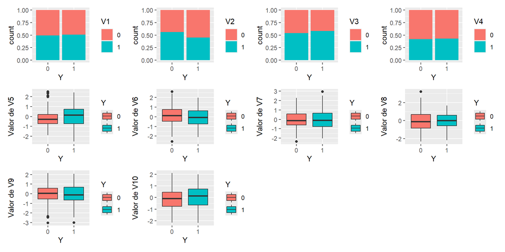

Despues de analizar las graficas del chunk “analisis_descriptivo” vimos que las variables se comportan casi igual cuando hay o no presencia de enfermedad

Entrenemos un modelo y veamos que tan bueno es nuestro poder predictivo y si las variables nos ayudan en algo

Comparación del poder predictivo entre modelos

| Modelo | Accuracy | Recall | Specificity |
| --- | --- | --- | --- |
| Logístico (efectos principales) | 0.494 | 0.502 | 0.485 |
| Logístico (interacciones completas) | 0.480 | 0.460 | 0.500 |
| Logístico (selección de variables) | 0.629 | 0.570 | 0.688 |
| Cloglog con selección BIC | 0.623 | 0.557 | 0.688 |
| LDA | 0.490 | 0.495 | 0.485 |
| QDA | 0.580 | 0.540 | 0.620 |
| Naive Bayes | 0.486 | 0.517 | 0.455 |
| KNN (con tuning) | 0.598 | 0.575 | 0.620 |

## Conclusiones

Hicimos los modelos que se muestran en la tabla anterior usando 5-CV como nuestra particion, el mejor modelo fue el logistico con seleccion de variables pues tiene la mejor tasa “Accuracy” y en el resto tambien destaca. El segundo modelo que tiene la mejor tasa es el modelo clolog con seleccion de variables y comparte las mismas interacciones entre variables que el mejor modelo, las cuales son: V4:V5, V7:V8, V9:V10, V4:V10, V5:V6 y V1:V2. Con lo cual podemos concluir que la seleccion de variables fue importante y que las interacciones antes mencionadas son las que tienen mayor poder predictivo.